# ProcessRespirationData

Tim T. Rademacher

May 20, 2018

## Processing respiration data in R

This document describes how to process respiration data recorded with a LICOR-820 using a custom made application. The data is processed using functions from the `'RespChamberProc'` package.

## Load packages and dependencies

First, we install and load all dependencies (`'segmented'` and `'tibble'`) and the R functions from `'RespChamberProc'` package.

```r
install.packages ('segmented', repos = 'http://cran.us.r-project.org')
```

```
##
##  '/tmp/RtmpumUx6l/downloaded_packages'
```

```r
install.packages ('tibble',    repos = 'http://cran.us.r-project.org')
```

```
##
##  '/tmp/RtmpumUx6l/downloaded_packages'
```

```r
library ('segmented')
library ('tibble')
fileList <- list.files (path = normalizePath ('../RespChamberProc/R/'))
# Nota bene: Brooklynn, you do not need to drop the 5th element. The commented line below should work fine.
fileList <- paste ('./', fileList [-5], sep = '')
#fileList <- paste ('./', fileList, sep = '')
res <- sapply (fileList, source, .GlobalEnv)
```

## Read Flulx Puppy output data

In the working directory there is a folder `'data/'` with the data files. The files are in two formats. The first output format from the LICOR app, which can be read in using the `'readDat'` function form the `'RespChamberProc'` package. The second output format is from the `'CO2 Flux Application'` and can be read in using the `'readApp'` function.

```r
readApp <- function (siteName, chamberID, sampleDate) {
  fileName  <-  list.files (path = '../data/',
                            pattern = paste ('G-',siteName,'_',chamberID,'_',format (sampleDate, format = '%Y%m%d'),'_', sep = ''))
  raw <- read.csv (file = paste ('../data/', fileName, sep = ''))
  names (raw) <- c ('Time.S', 'CO2.ppm', 'H20.ppm', 'Temperature.C', 'Pressure.kPa')
  return (raw)
}
```

```r
studyName     <- 'Exp2017'
treeID        <- 10
treatment     <- 3
chamberNumber <- 3
chamberID     <- paste (treeID,'p',treatment,'p',chamberNumber,sep = '')
samplingDate  <- as.POSIXct ('20180509', format = '%Y%m%d')
```

```r
raw <- readApp (siteName = studyName, chamberID = chamberID, sampleDate = samplingDate)
```

We also need to extract the exact time from the file name and combine it with the date. I am currently assuming that the app saves time as EDT and not EST.

```r
fileName  <-  list.files (path = '../data/', pattern = paste ('G-',studyName,'_',chamberID,'_',format (samplingDate, format = '%Y%m%d'),'_', sep = ''))
Time.H.M.S <- (substr (fileName, nchar (fileName)-10+1, nchar (fileName)-4))
dateAndTime <- strptime (paste (samplingDate, Time.H.M.S), format = '%Y-%m-%d %H%M%S')
```

## Pre-processing flux puppy output data

The first processing step is to plot the raw CO<sub>2</sub> data and determine the appropriate window to analyse. Ideally, we have a linearly increasing portion of the CO<sub>2</sub> concentration that we can isolate for analysis.

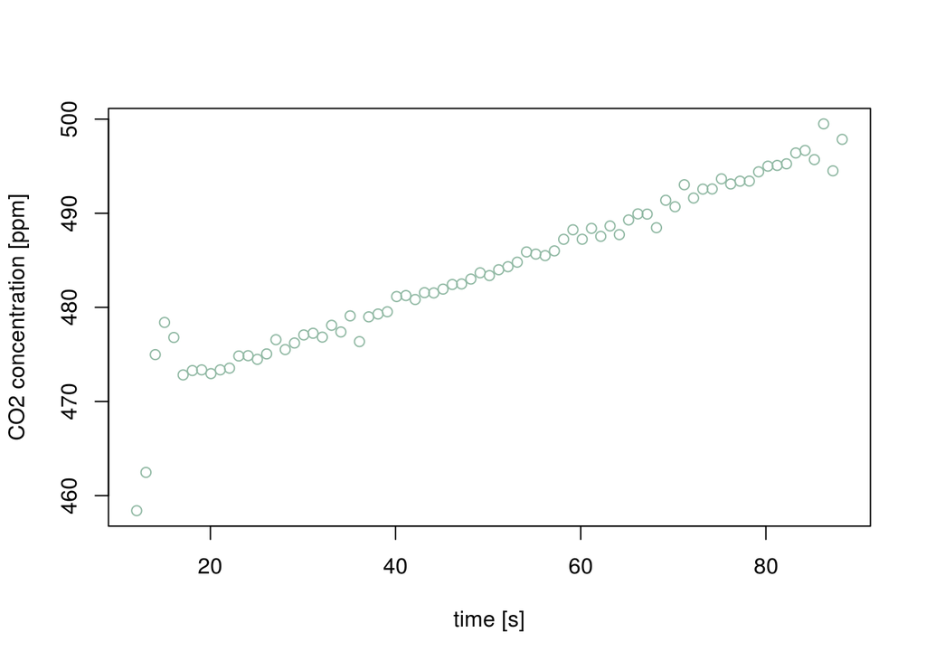

Sometimes, like in this example, there will be some lag because the measurement started before the chamber was closed and attained a dynamic equilibrium. We can use the `'selectData'` function to select only the data after the lag.

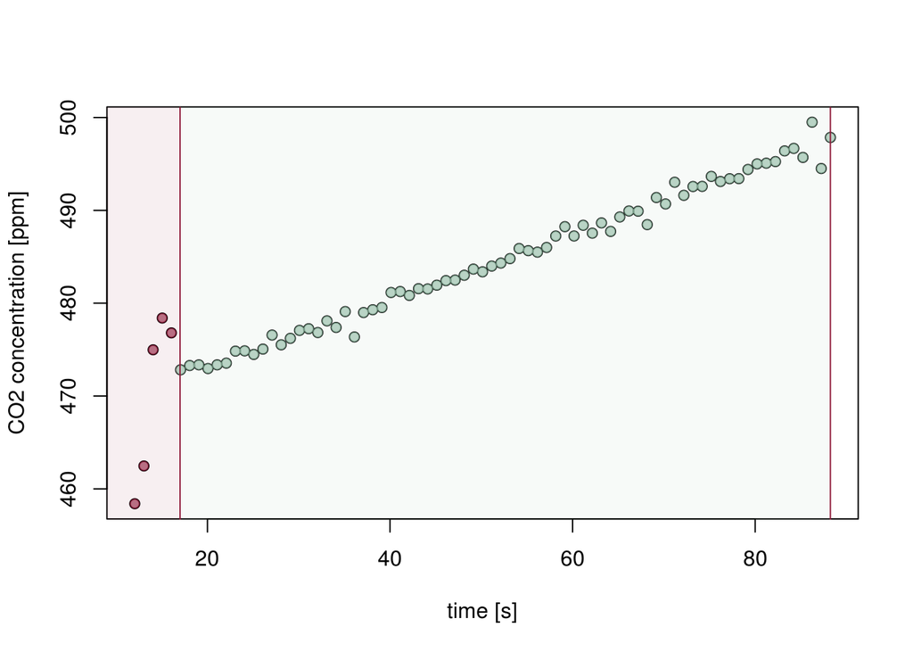

```r
selectData <- function (ds = raw, colConc = 'CO2.ppm', colTime = 'Time.S', lowerBound = 0, upperBound = 1e6) {
  # make sure upperBound is not higher than the length of the time series
  upperBound <- min (upperBound, max (ds [[colTime]]))
  # make sure lowerBound is not lower than the starting point of the time series
  lowerBound <- max (lowerBound, min (ds [[colTime]]))
  # select appropriate data
  dat <- ds [(ds [[colTime]] >= lowerBound) &
             (ds [[colTime]] <= upperBound), ]
  cut <- ds [(ds [[colTime]] < lowerBound) |
             (ds [[colTime]] > upperBound), ]
  # plot data
  plot (x = ds [[colTime]],
        y = ds [[colConc]],
        xlab = 'time [s]',
        ylab = 'CO2 concentration [ppm]')
  # plot selected data bounds
  points (x = dat [[colTime]],
          y = dat [[colConc]],
          col  = '#91b9a499',
          pch  = 19,
          cex  = 0.9)
  rect (xleft   = lowerBound,
        xright  = upperBound,
        ybottom = 0,
        ytop    = 100000,
        col     = '#91b9a411',
        border  = '#901C3B')
  # plot highlight cut data
  points (x = cut [[colTime]],
          y = cut [[colConc]],
          col  = '#901C3B99',
          pch  = 19,
          cex  = 0.9)
  rect (xleft   = 0,
        xright  = lowerBound,
        ybottom = 0,
        ytop    = 100000,
        col     = '#901C3B11',
        lty     = 0)
  return (dat)
}
dat <- selectData (ds = raw,
                   lowerBound = 17,
                   upperBound = 89)
```

There is another option with the `'selectDataAfterLag'` function from the `'RespChamberProc'` package, which does select data after an initial lag automatically, but I prefer concatenating data at both ends manually, as necessary.

Now we got a cleaned time series, we can calcualte the chamber geometry using the appropriate chamber geometry function (either `'chamberGeometryCuboid'` or `'chamberGeometryCylinder'`). My chambers were cylinders with a radius of roughly 2" or 5cm and a height of roughly 4" or 10cm.

```r
chamberGeometry <- calcChamberGeometryCylinder (radius = 0.0508,
                                                height = 0.1016,
                                                taper  = 1.0)
```

This results in a chamber volume of 0.00082m<sup>3</sup>.

# Obtain and process suitable meteorological data

```r
# Get appropriate meterological data
if (samplingDate < as.POSIXct ('2018-04-01', format = '%Y-%m-%d')) {
  met_HF <- read.csv (file = url ('http://harvardforest.fas.harvard.edu/sites/harvardforest.fas.harvard.edu/files/data/p00/hf001/hf001-10-15min-m.csv'))
} else if (samplingDate >= as.POSIXct ('2018-04-01', format = '%Y-%m-%d')) {
  met_HF <- read.csv (file = url ('http://harvardforest.fas.harvard.edu/sites/harvardforest.fas.harvard.edu/files/weather/qfm.csv'))
}
met_HF$TIMESTAMP <- as.POSIXct (met_HF$datetime,
                                format = '%Y-%m-%dT%H:%M',
                                tz = 'EST')

# Determine which measurement to use, N.B. data is named after the time at the end of the 15 minute interval
upper_bound <- as.POSIXct (x      = round (as.numeric (median (dateAndTime + raw$Time.S))/
                                    (15 * 60)) * (15 * 60) + (15 * 60),
                           format = '%Y-%m-%d %H:%M:%S',
                           origin = as.POSIXct ("1970-01-01", format = '%Y-%m-%d', tz = 'UTC'),
                           tz = 'EST')

pres.Pa <- met_HF$bar  [met_HF$TIMESTAMP == upper_bound] * 100.0 # Pa
airt.C  <- met_HF$airt [met_HF$TIMESTAMP == upper_bound]         # deg C
rh.per  <- met_HF$rh   [met_HF$TIMESTAMP == upper_bound]         # %
```

With the meteorological data we can determine absolute water vapour pressure (in parts per thousand) and add it and the other meteorological variables to the raw respiration data.frame.

```r
# Calculate saturation water vapour pressure (esat) to convert relative humidity
es.Pa <- 0.61078 * exp ((17.269 * airt.C) / (237.3 + airt.C)) * 1000 # saturated water pressure [Pa]
ea.Pa <- es.Pa * rh.per / 100.0                                         # get actual water vapour pressure [Pa]
dat$ea.Pa   <- rep (ea.Pa,   length (dat [, 1]))   # add actual water vapour pressure [Pa] to raw data.frame
dat$airt.C  <- rep (airt.C,  length (dat [, 1]))   # add air temperature [degC] to raw data.frame
dat$pres.Pa <- rep (pres.Pa, length (dat [, 1]))   # add atmospheric pressure [Pa] to raw data.frame
dat$H2O.ppt <- dat$ea.Pa / (dat$pres.Pa - dat$ea.Pa) * 1.0e3   # add actual water vapour pressure [ppt] to raw data.frame
```

## Process data to estimate respiration flux

We can then correct for the atmospheric water vapour pressure (`'H2O.ppt'`) to get the CO<sub>2</sub> concentration of dry air (`'CO2.dry'`).

```r
# Correct CO2 concentration for water vapour
dat$CO2.dry <- corrConcDilution (dat,
                                 colConc   = 'CO2.ppm',
                                 colVapour = 'H2O.ppt')
```

From the dry concentration of CO<sub>2</sub> in dry air (`'CO2.dry'`), the chamber size, the air temperature (`'tair.C'`) and the atmospheric (`'pres.Pa'`) at the time we can calculate the respiration flux using the `'calcClosedChamberFlux'` of the `'RespChamberProc'` package.

```r
# Calculate chamber flux for entire timeseries
resFit <- calcClosedChamberFlux (dat,
                                 colConc     = 'CO2.dry',
                                 colTime     = 'TIMESTAMP', # redundant
                                 colTemp     = 'airt.C',
                                 colPressure = 'pres.Pa',
                                 volume      = chamberGeometry [1],
                                 area        = chamberGeometry [2])
```

We want to plot the resulting fit, to look at it again.

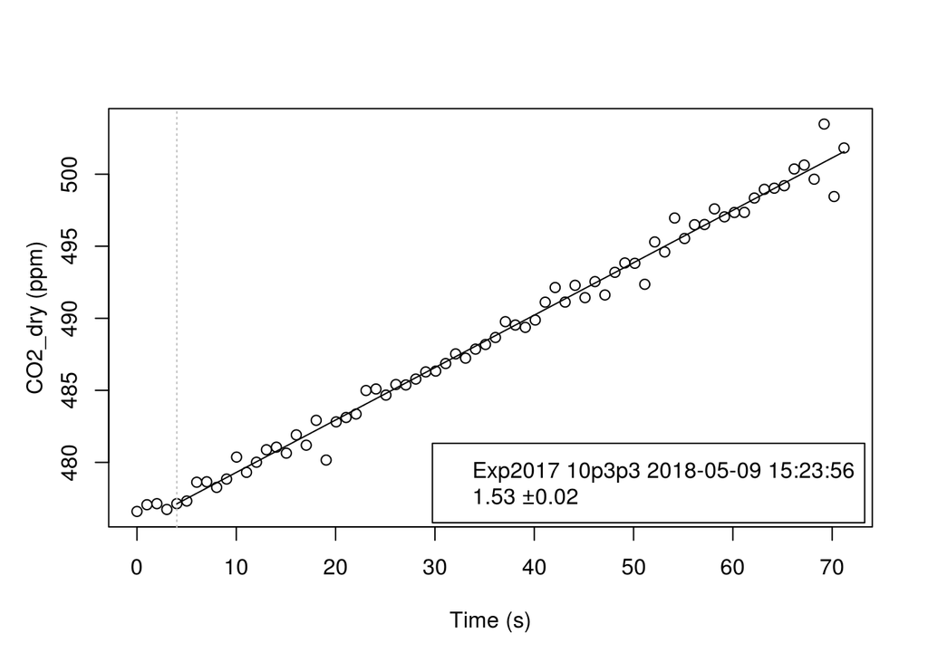

```r
plotResp (dat,
          resFlux = resFit,
          colConc = 'CO2.dry',   # redundant
          colTime = 'TIMESTAMP', # redundant
          label = paste (studyName, paste (treeID,'p',treatment,'p',chamberNumber,sep = ''),dateAndTime))
```

If there is no problem, we want to save the plot and the fit to a data structure with the results in the `'fig/'` directory.

```r
fileName2 <- substr (fileName, 1, nchar (fileName)-4)
png (file = paste ('fig/',fileName2,'.png', sep = ''))
plotResp (dat,
          resFlux = resFit,
          colConc = 'CO2.dry',   # redundant
          colTime = 'TIMESTAMP', # redundant
          label = paste (studyName, paste (treeID,'p',treatment,'p',chamberNumber,sep = ''),dateAndTime))
dev.off ()
```

Now, we can add the resulting fit (`'resFit'`) to the data.frame containning site names, etc.

## Processing multiple files

If you have multiple files, you may want to analyse all of them and add the results to a single data.frame. For the example, here I assume that all `csv` files in the `data/` directory are intended to be analysed. First, you make a list of all files in the `data/` directory.

```r
# Create list of all csv files in the data/ directory
fileNames <- list.files (path = '../data/', pattern = '.csv')
```

Next, dates and times for all files are extracted.

```r
# Isolate the important part of the string
tmp <- unlist (strsplit (fileNames, '_'))
datestr <- tmp [seq (3, length (tmp), 4)]
timestr <- tmp [seq (4, length (tmp), 4)]
timestr <- substring (timestr, 1, nchar (timestr) - 4)

# put the dates and times together
datesAndTimes <- strptime (paste (datestr, timestr), "%Y%m%d %H%M%S")
```

And finally the data.frame for all results is created.

```r
# Create the data.frame
alldata <- data.frame (file = fileNames,date = datesAndTimes, stringsAsFactors = FALSE)
```